# assignment03

Jeff Nguyen

03/09/2020

**University of Southern California**  
**Marshall School of Business**  
**FBE 506 Quantitative Method in Finance**

Assignment 03  
Student Name: Ngoc Son (Jeff) Nguyen  
Student ID: 6524885309

# **Question 1**

For continuous functions defined by $y= f(x)$, the point $(x_0,f(x_0))$ is a maxima or minima if $x_0$ is in the domain of the function and $f'(x) = 0$. Thus, for the below, we find and test extrema values $x_0$ for which $f'(x_0) = 0$.

## a. $y = x^2 - 6x + 5$

This is a polynomial function, thus, it is continuous everywhere. We know:

$$\begin{equation}
\begin{aligned}
f'(x_0) & = 0 \\
\frac{dy}{dx} & = 0 \\
2x - 6 & = 0 \\
x & = 3
\end{aligned}
\end{equation}$$

**Thus, we have the critical point $x_0 = 3$**

**Graph of the function:**

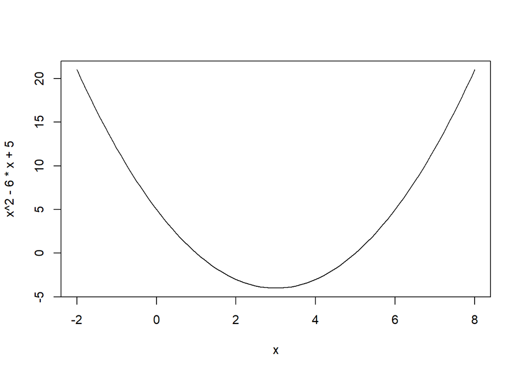

```r
curve(x^2 - 6*x + 5, -2, 8)
```

Testing for min, max:
$$\begin{equation}
\begin{aligned}
f'(x_0-1) & = f'(2) \qquad & f'(x_0+1) & = f'(4) \\
f'(x_0-1) & = 2(2) - 6 & f'(x_0+1) & = 2(4) - 6 \\
f'(x_0-1) & = -2 < 0 & f'(x_0+1) & = 2 > 0
\end{aligned}
\end{equation}$$

Finding $f(3)$:
$$\begin{equation}
\begin{aligned}
f(3) & = 3^2 - 6(3) + 5 \\
f(3) & = -4
\end{aligned}
\end{equation}$$

**We see that the function is decreasing on $(-\infty,3)$, and increasing on $(3,\infty)$** **Thus, the absolute minima of the function is at $(3,-4)$**

Finding inflection point:
$$\begin{equation}
\begin{aligned}
f''(x_0) & = 0 \\
\frac{d^2 y}{dx^2} & = 0 \\
2 & = 0 \text{ (not possible)}
\end{aligned}
\end{equation}$$

**Thus the inflection point does not exist for this function.**

## b. $y = -x^2 + 6x - 5$

This is a polynomial function, thus, it is continuous everywhere. We know:

$$\begin{equation}
\begin{aligned}
f'(x_0) & = 0 \\
\frac{dy}{dx} & = 0 \\
-2x + 6 & = 0 \\
x & = 3
\end{aligned}
\end{equation}$$

**Thus we have the critical point $x_0 = 3$**

**Graph of the function:**

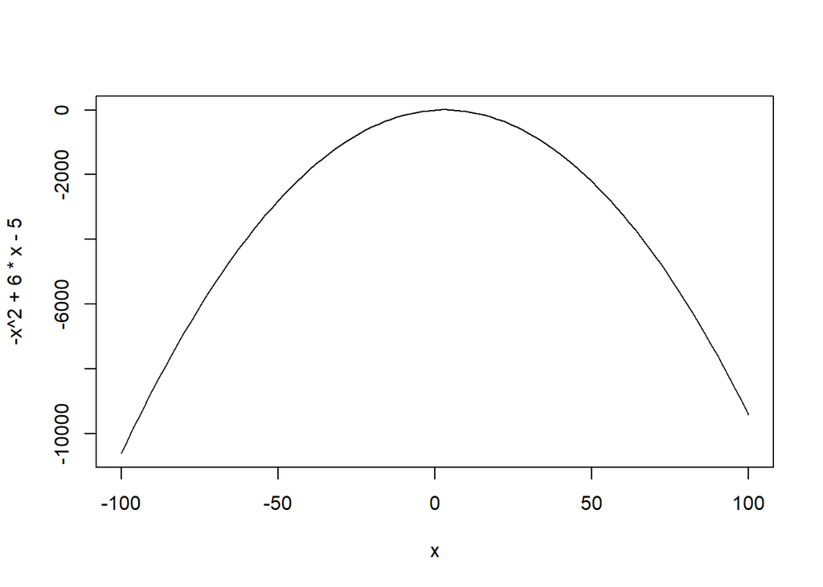

```r
curve(-x^2 + 6*x - 5, -100,100)
```

Testing for min, max:
$$\begin{equation}
\begin{aligned}
f'(x_0 - 1) & = f'(2) \qquad & f'(x_0 + 1) & = f'(4) \\
f'(x_0 - 1) & = -2(2) + 6 & f'(x_0 + 1) & = -2(4) + 6 \\
f'(x_0 - 1) & = 4 > 0 & f'(x_0 + 1) & = -2 < 0
\end{aligned}
\end{equation}$$

Finding $f(3)$:
$$\begin{equation}
\begin{aligned}
f(3) & = -3^2 + 6(3) - 5 \\
f(3) & = 4
\end{aligned}
\end{equation}$$

**We see that the function is increasing on $(-\infty,3)$, and decreasing on $(3,\infty)$** **Thus, the absolute maxima of the function is at $(3,4)$**

Finding inflection point:
$$\begin{equation}
\begin{aligned}
f''(x_0) & = 0 \\
\frac{d^2 y}{dx^2} & = 0 \\
-2 & = 0 \text{ (not possible)}
\end{aligned}
\end{equation}$$

**Thus the inflection point does not exist for this function.**

## c. $y = 2x^3 - 15x^2 + 36x + 10$

This is a polynomial function, thus, it is continuous everywhere. We know:

$$\begin{equation}
\begin{aligned}
f'(x_0) & = 0 \\
\frac{dy}{dx} & = 0 \\
6x^2 - 30x + 36 & = 0 \\
x & = \frac{-b \pm \sqrt{b^2 - 4ac}}{2a} \\
x & = \frac{-(-30) \pm \sqrt{(-30)^2 - 4(6)(36)}}{2(6)} \\
x & = \frac{30 \pm \sqrt{36}}{12} \\
x & =
\left\{
\begin{array} {l}
3 \\
2
\end{array}
\right.
\end{aligned}
\end{equation}$$

Thus we have the potential extremas $x_0 = 3$ and $x_0 = 2$

**Graph of the function:**

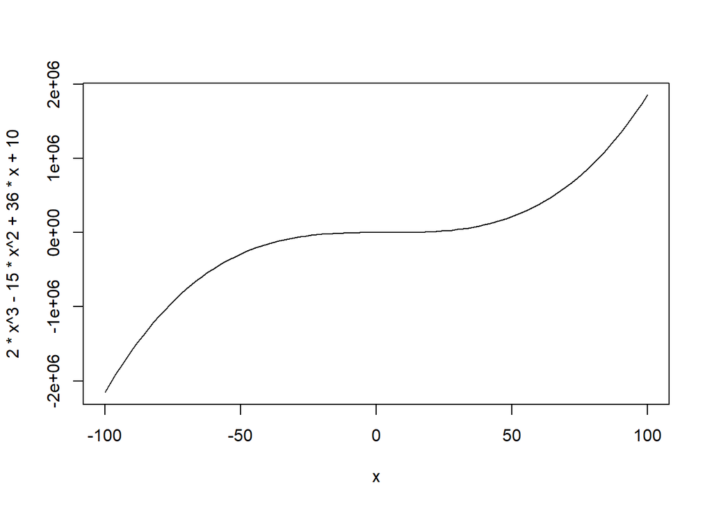

```r
curve(2*x^3 - 15*x^2 + 36*x + 10, -100,100)
```

Testing min, max with $x_0 = 3$
$$\begin{equation}
\begin{aligned}
f'(x_0 - \frac{1}{4}) & = f'(\frac{11}{4}) \qquad & f'(x_0 + 1) & = f'(4) \\
f'(x_0 - \frac{1}{4}) & = 6(\frac{11}{4})^2 - 30(\frac{11}{4}) + 36 & f'(x_0 + 1) & = 6(4)^2 - 30(4) + 36 \\
f'(x_0 - \frac{1}{4}) & = -\frac{9}{8} < 0 & f'(x_0 + 1) & = 12 > 0 \\
\end{aligned}
\end{equation}$$

Finding $f(3)$:
$$\begin{equation}
\begin{aligned}
f(3) & = 2(3)^3 - 15(3)^2 + 36(3) + 10 \\
f(3) & = 37
\end{aligned}
\end{equation}$$

**From the above, we gather the function is decreasing just before $(3,37)$ and increasing right after $(3,37)$** **Thus, the function has a local minima at $(3,37)$**

Testing min, max with $x_0 = 2$
$$\begin{equation}
\begin{aligned}
f'(x_0 - \frac{1}{4}) & = f'(\frac{7}{4}) \qquad & f'(x_0 + \frac{1}{4}) & = f'(\frac{9}{4}) \\
f'(x_0 - \frac{1}{4}) & = 6(\frac{7}{4})^2 - 30(\frac{7}{4}) + 36 & f'(x_0 + \frac{1}{4}) & = 6(\frac{9}{4})^2 - 30(\frac{9}{4}) + 36 \\
f'(x_0 - \frac{1}{4}) & = \frac{15}{8} > 0 & f'(x_0 + \frac{1}{4}) & = -\frac{9}{8} < 0 \\
\end{aligned}
\end{equation}$$

Finding $f(2)$:
$$\begin{equation}
\begin{aligned}
f(2) & = 2(2)^3 - 15(2)^2 + 36(2) + 10 \\
f(2) & = 38
\end{aligned}
\end{equation}$$

**From the above, we gather the function is increasing just before $(2,38)$ and decreasing right after $(2,38)$** **Thus, the function has a local maxima at $(2,38)$**

**The function does not have absolute minima nor maxima.**

Finding inflection point:
$$\begin{equation}
\begin{aligned}
f''(x_0) & = 0 \\
\frac{d^2 y}{dx^2} & = 0 \\
12x - 30 & = 0 \\
x & = \frac{5}{2}
\end{aligned}
\end{equation}$$

Testing the potential inflection point $(\frac{5}{2},f(\frac{5}{2}))$ :
$$\begin{equation}
\begin{aligned}
f''(x_0 - \frac{1}{2}) & = f''(2) \qquad & f''(x_0 + \frac{1}{2}) & = f''(3) \\
f''(x_0 - \frac{1}{2}) & = 12(2) - 30 & f''(x_0 + \frac{1}{2}) & = 12(3) - 30 \\
f''(x_0 - \frac{1}{2}) & = -6 < 0 & f''(x_0 + \frac{1}{2}) & = 6 > 0 \\
\end{aligned}
\end{equation}$$

Finding $f(\frac{5}{2})$:
$$\begin{equation}
\begin{aligned}
f(\frac{5}{2}) & = 2(\frac{5}{2})^3 - 15(\frac{5}{2})^2 + 36(\frac{5}{2}) + 10 \\
f(\frac{5}{2}) & = \frac{75}{2}
\end{aligned}
\end{equation}$$

**Thus $(\frac{5}{2}, \frac{75}{2})$ is an inflection point and is where the function curvature changes from concave to convex.**

## d. $y = x^3 -3x^2 +3x$

This is a polynomial function, thus, it is continuous everywhere. We know:

$$\begin{equation}
\begin{aligned}
f'(x_0) & = 0 \\
\frac{dy}{dx} & = 0 \\
3x^2 -6x + 3 & = 0 \\
x & = \frac{-b \pm \sqrt{b^2 - 4ac}}{2a} \\
x & = \frac{-(-6) \pm \sqrt{(-6)^2 - 4(3)(3)}}{2(3)} \\
x & = \frac{6 \pm \sqrt{0}}{6} \\
x & = 1
\end{aligned}
\end{equation}$$

Thus we have the potential extrema $x_0 = 1$

Graph of the function:

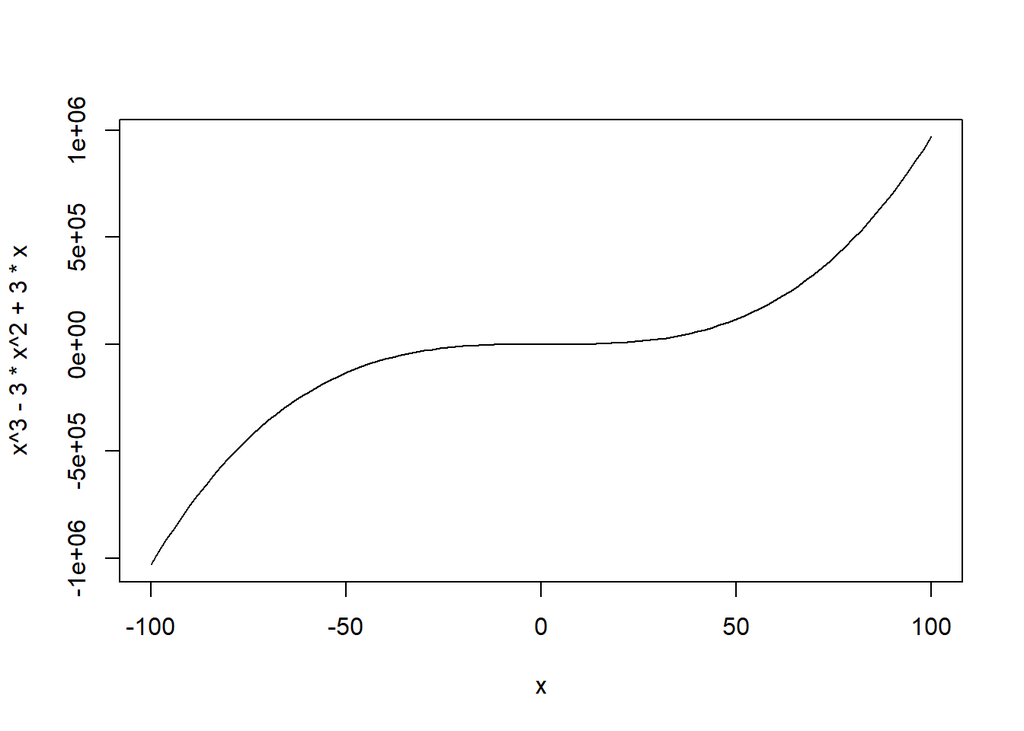

```r
curve(x^3 -3*x^2 +3*x, -100,100)
```

Testing min, max with $x_0 = 1$
$$\begin{equation}
\begin{aligned}
f'(x_0 - 1) & = f'(0) \qquad & f'(x_0 + 1) & = f'(2) \\
f'(x_0 - 1) & = 3(0)^2 - 6(0) + 3 & f'(x_0 + 1) & = 3(2)^2 - 6(2) + 3 \\
f'(x_0 - 1) & = 3 > 0 & f'(x_0 + 1) & = 3 > 0
\end{aligned}
\end{equation}$$

Finding $f(1)$:
$$\begin{equation}
\begin{aligned}
f(1) & = 1^3 - 3(1)^2 + 3(1) \\
f(1) & = 1
\end{aligned}
\end{equation}$$

**From the above, we know the function increasing past $(1,1)$ and there is no local or absolute minima or maxima.**

Finding inflection point:
$$\begin{equation}
\begin{aligned}
f''(x_0) & = 0 \\
\frac{d^2 y}{dx^2} & = 0 \\
6x - 6 & = 0 \\
x & = 1
\end{aligned}
\end{equation}$$

Testing the potential inflection point at $x_0 = 1$
$$\begin{equation}
\begin{aligned}
f''(x_0 - 1) & = f''(0) \qquad & f''(x_0 + 1) & = f''(2) \\
f''(x_0 - 1) & = 6(0) - 6 & f''(x_0 + 1) & = 6(2) - 6 \\
f''(x_0 - 1) & = -6 < 0 & f''(x_0 + 1) & = 6 > 0
\end{aligned}
\end{equation}$$

**From the test, we see that the function curvature changes from concave to convex at $(1,1)$, thus $(1,1)$ is an inflection point.**

## e. $y = (x-1)^3$

This is a polynomial function, thus, it is continuous everywhere. Expanding:

$$\begin{equation}
\begin{aligned}
f(x) & = (x-1) ^3 \\
& = (x-1)(x^2 - 2x + 1) \\
& = x^3 - 2x^2 + x - x^2 + 2x - 1 \\
& = x^3 - 3x^2 + 3x - 1 \\
\end{aligned}
\end{equation}$$

Finding min, max:

$$\begin{equation}
\begin{aligned}
f'(x_0) & = 0 \\
\frac{dy}{dx} & = 0 \\
3x^2 - 6x + 3 & = 0 \\
x^2 - 2x + 1 & = 0 \\
(x-1)^2 & = 0 \\
x & = 1
\end{aligned}
\end{equation}$$

Thus we have the potential extrema $x_0 = 1$

Graph of the function:

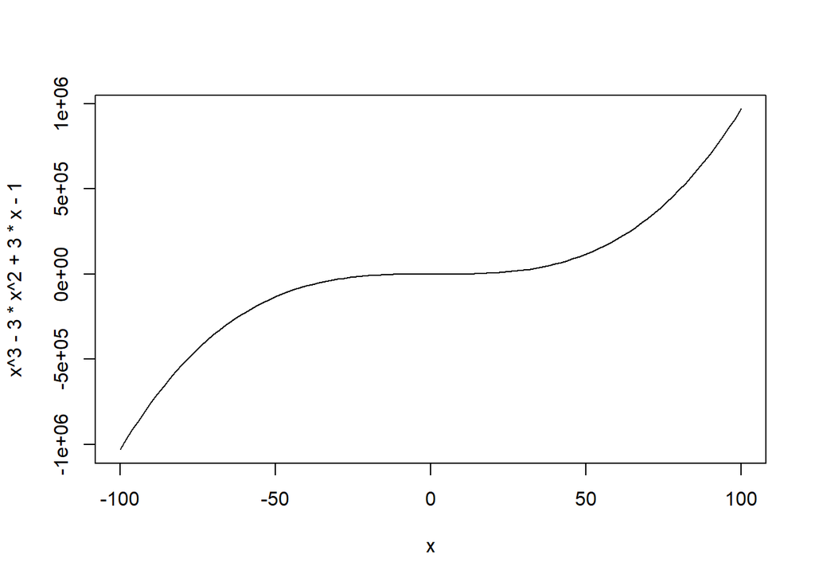

```r
curve(x^3 - 3*x^2 + 3*x - 1, -100,100)
```

Testing min, max with $x_0 = 1$
$$\begin{equation}
\begin{aligned}
f'(x_0 - 1) & = f'(0) \qquad & f'(x_0 + 1) & = f'(2) \\
f'(x_0 - 1) & = (0-1)^2 & f'(x_0 + 1) & = (2-1)^2 \\
f'(x_0 - 1) & = 1 > 0 & f'(x_0 + 1) & = 1 > 0
\end{aligned}
\end{equation}$$

Finding $f(1)$:
$$\begin{equation}
\begin{aligned}
f(1) & = (1-1)^3 \\
f(1) & = 0
\end{aligned}
\end{equation}$$

**From the above, we know the function increasing past $(1,0)$ and there is no local or absolute minima or maxima.**

Finding inflection point:
$$\begin{equation}
\begin{aligned}
f''(x_0) & = 0 \\
\frac{d^2 y}{dx^2} & = 0 \\
2x - 2 & = 0 \\
x & = 1
\end{aligned}
\end{equation}$$

Testing the potential inflection point at $x_0 = 1$
$$\begin{equation}
\begin{aligned}
f''(x_0 - 1) & = f''(0) \qquad & f''(x_0 + 1) & = f''(2) \\
f''(x_0 - 1) & = 2(0) - 2 & f''(x_0 + 1) & = 2(2) - 2 \\
f''(x_0 - 1) & = -2 < 0 & f''(x_0 + 1) & = 2 > 0
\end{aligned}
\end{equation}$$

**From the test, we see that the function curvature changes from concave to convex at $(1,0)$, thus $(1,0)$ is an inflection point.**

## f. $y = (x^2 - 1)^2$

This is a polynomial function, thus, it is continuous everywhere. Expanding:

$$\begin{equation}
\begin{aligned}
f(x) & = (x^2 - 1)^2 \\
& = x^4 - 2x^2 + 1
\end{aligned}
\end{equation}$$

Finding min, max:

$$\begin{equation}
\begin{aligned}
f'(x_0) & = 0 \\
\frac{dy}{dx} & = 0 \\
4x^3 - 4x & = 0 \\
4x(x^2 - 1) & = 0 \\
4x(x - 1)(x + 1) & = 0 \\
x & =
\left\{
\begin{array} {l}
0 \\
1 \\
-1
\end{array}
\right.
\end{aligned}
\end{equation}$$

Thus we have the potential extrema $x_0 = -1$, $x_0 = 0$ and $x_0 = 1$

Graph of the function:

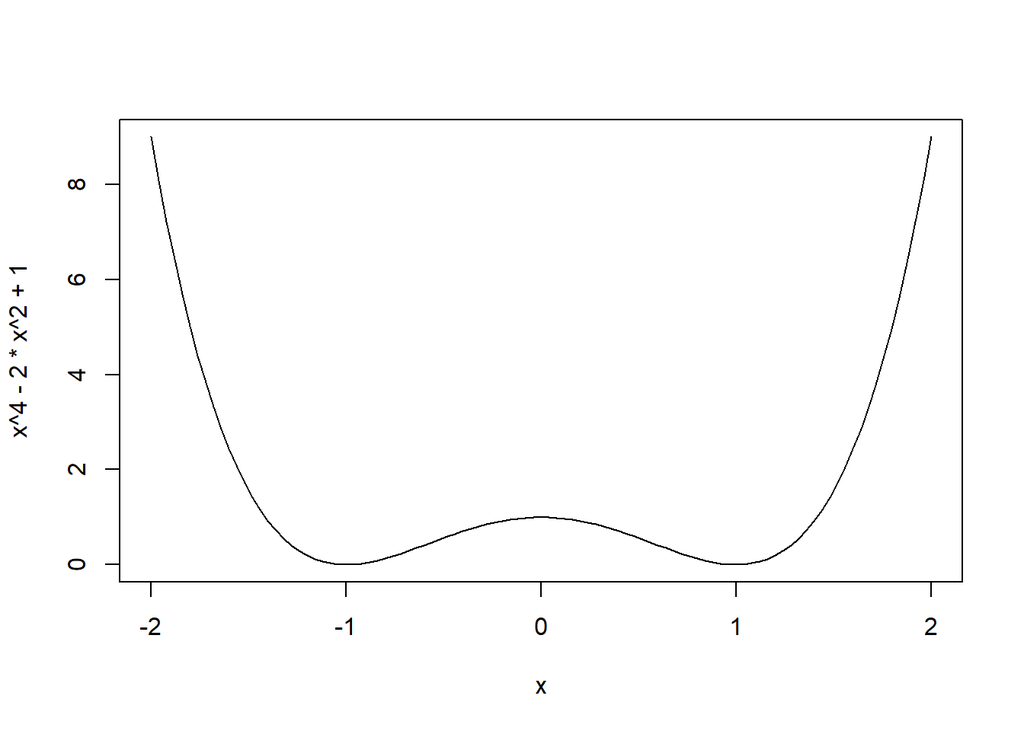

```r
curve(x^4 - 2*x^2 + 1, -2,2)
```

Testing min, max with $x_0 = -1$
$$\begin{equation}
\begin{aligned}
f'(x_0 - 1) & = f'(-2) \qquad & f'(x_0 + \frac{1}{4}) & = f'(-3/4) \\
f'(x_0 - 1) & = 4(-2)^3 - 4(-2) & f'(x_0 + \frac{1}{4}) & = 4(-3/4)^3 - 4(-3/4) \\
f'(x_0 - 1) & = -24 < 0 & f'(x_0 + \frac{1}{4}) & = 21/16 > 0
\end{aligned}
\end{equation}$$

Finding $f(-1)$:
$$\begin{equation}
\begin{aligned}
f(1) & = (-1)^4 - 2(-1)^2 + 1 \\
f(1) & = 0
\end{aligned}
\end{equation}$$

**From the above, we know the function has a local min at $(-1,0)$.**

Testing min, max with $x_0 = 0$
$$\begin{equation}
\begin{aligned}
f'(x_0 - \frac{1}{4}) & = f'(-\frac{1}{4}) \qquad & f'(x_0 + \frac{1}{4}) & = f'(1/4) \\
f'(x_0 - \frac{1}{4}) & = 4(-\frac{1}{4})^3 - 4(-\frac{1}{4}) & f'(x_0 + \frac{1}{4}) & = 4(1/4)^3 - 4(1/4) \\
f'(x_0 - \frac{1}{4}) & = \frac{15}{16} > 0 & f'(x_0 + \frac{1}{4}) & = -15/16 < 0
\end{aligned}
\end{equation}$$

Finding $f(0)$:
$$\begin{equation}
\begin{aligned}
f(1) & = (0)^4 - 2(0)^2 + 1 \\
f(1) & = 1
\end{aligned}
\end{equation}$$

**From the above, we know the function has a local max at $(0,1)$.**

Testing min, max with $x_0 = 1$
$$\begin{equation}
\begin{aligned}
f'(x_0 - \frac{1}{4}) & = f'(frac{3}{4}) \qquad & f'(x_0 + 1) & = f'(2) \\
f'(x_0 - \frac{1}{4}) & = 4(\frac{3}{4})^3 - 4(\frac{3}{4}) & f'(x_0 + 1) & = 4(2)^3 - 4(2) \\
f'(x_0 - \frac{1}{4}) & = -\frac{21}{16} < 0 & f'(x_0 + 1) & = 24 > 0
\end{aligned}
\end{equation}$$

Finding $f(1)$:
$$\begin{equation}
\begin{aligned}
f(1) & = (1)^4 - 2(1)^2 + 1 \\
f(1) & = 0
\end{aligned}
\end{equation}$$

Finding inflection point:
$$\begin{equation}
\begin{aligned}
f''(x_0) & = 0 \\
\frac{d^2 y}{dx^2} & = 0 \\
12x^2 - 4 & = 0 \\
3x^2 - 1 & = 0 \\
x^2 & = \frac{1}{3} \\
x & =
\left\{
\begin{array} {l}
\frac{1}{\sqrt{3}} \\
-\frac{1}{\sqrt{3}}
\end{array}
\right.
\end{aligned}
\end{equation}$$

Testing the potential inflection point at $x_0 = -\frac{1}{\sqrt{3}}$
$$\begin{equation}
\begin{aligned}
f''(x_0 - \frac{2}{\sqrt{3}}) & = f''(-\sqrt{3}) \qquad & f''(x_0 + \frac{1}{\sqrt{3}}) & = f''(0) \\
f''(x_0 - \frac{2}{\sqrt{3}}) & = 12(-\sqrt{3})^2 - 4 & f''(x_0 + \frac{1}{\sqrt{3}}) & = 12(0)^2 - 4 \\
f''(x_0 - \frac{2}{\sqrt{3}}) & = 32 > 0 & f''(x_0 + \frac{1}{\sqrt{3}}) & = -4 < 0
\end{aligned}
\end{equation}$$

Finding $f(-\frac{1}{\sqrt{3}})$:
$$\begin{equation}
\begin{aligned}
f(-\frac{1}{\sqrt{3}}) & = (-\frac{1}{\sqrt{3}})^4 - 2(-\frac{1}{\sqrt{3}})^2 + 1 \\
f(-\frac{1}{\sqrt{3}}) & = \frac{4}{9}
\end{aligned}
\end{equation}$$

**From the test, we see that the function curvature changes from convex to concave at $(-\frac{1}{\sqrt{3}},\frac{4}{9})$, thus $(-\frac{1}{\sqrt{3}},\frac{4}{9})$ is an inflection point.**

Testing the potential inflection point at $x_0 = \frac{1}{\sqrt{3}}$
$$\begin{equation}
\begin{aligned}
f''(x_0 - \frac{1}{\sqrt{3}}) & = f''(0) \qquad & f''(x_0 + \frac{2}{\sqrt{3}}) & = f''(\sqrt{3}) \\
f''(x_0 - \frac{1}{\sqrt{3}}) & = 12(0)^2 - 4 & f''(x_0 + \frac{2}{\sqrt{3}}) & = 12(\sqrt{3})^2 - 4 \\
f''(x_0 - \frac{1}{\sqrt{3}}) & = -4 < 0 & f''(x_0 + \frac{2}{\sqrt{3}}) & = 32 > 0
\end{aligned}
\end{equation}$$

Finding $f(\frac{1}{\sqrt{3}})$:
$$\begin{equation}
\begin{aligned}
f(\frac{1}{\sqrt{3}}) & = (\frac{1}{\sqrt{3}})^4 - 2(\frac{1}{\sqrt{3}})^2 + 1 \\
f(\frac{1}{\sqrt{3}}) & = \frac{4}{9}
\end{aligned}
\end{equation}$$

**From the test, we see that the function curvature changes from concave to convex at $(\frac{1}{\sqrt{3}},\frac{4}{9})$, thus $(\frac{1}{\sqrt{3}},\frac{4}{9})$ is also an inflection point.**

## g. $y = \ln{\frac{x+1}{x^2+3}}$

We know that $\ln(X)$ is continuous on $(0,\infty)$.

Thus the domain of y is:
$$\begin{equation}
\begin{aligned}
\left\{
\begin{array} {l}
x^2 + 3 > 0 \forall x \in \mathbf{R} \\
x + 1 > 0 \Leftrightarrow \forall x \in (-1,\infty)
\end{array}
\right.
\end{aligned}
\end{equation}$$

Finding min, max:
$$\begin{equation}
\begin{aligned}
f'(x_0) & = 0 \\
\frac{dy}{dx} & = 0 \\
\frac{d(\ln{\frac{x+1}{x^2+3}})}{dx} & = 0 \\
\frac{\frac{1}{\frac{x+1}{x^2+3}}.d\frac{x+1}{x^2+3}}{dx} & = 0 \\
\frac{x^2+3}{x+1}.\Big[(x+1).d(\frac{1}{x^2+3}) + d(x+1).\frac{1}{x^2+3} \Big] & = 0 \\
\frac{x^2+3}{x+1}.\Big[\frac{-(x+1).d(x^2+3)}{(x^2+3)^2} + \frac{1}{x^2+3} \Big] & = 0 \\
\frac{x^2+3}{x+1}.\frac{-2x(x+1) + x^2 + 3}{(x^2 + 3)^2} & = 0 \\
\frac{-2x^2 - 2x + x^2 + 3}{(x^2+3)(x+1)} & = 0 \\
\frac{-x^2 - 2x + 3}{(x^2+3)(x+1)} & = 0 \\
-x^2 - 2x + 3 & = 0 \\
x & = \frac{-b \pm \sqrt{b^2 - 4ac}}{2a} \\
x & = \frac{-(-2) \pm \sqrt{(-2)^2 - 4(-1)(3)}}{2(-1)} \\
x & = \frac{2 \pm \sqrt{16}}{-2} \\
x & =
\left\{
\begin{array} {l}
1 \\
-3 \text{ ,not valid as x > -1}
\end{array}
\right.
\end{aligned}
\end{equation}$$

Thus we have the potential extrema $x_0 = 1$

Graph of the function:

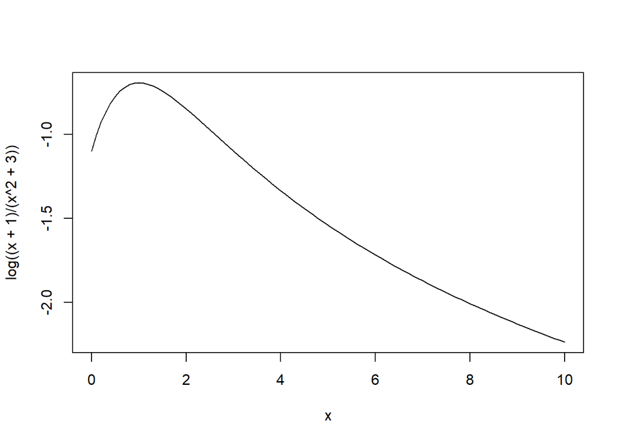

```r
curve(log((x+1)/(x^2+3)), 0.0000001,10)
```

Testing min, max with $x_0 = 1$
$$\begin{equation}
\begin{aligned}
f'(x_0 - \frac{1}{2}) & = f'(\frac{1}{2}) \qquad & f'(x_0 + \frac{1}{2}) & = f'(\frac{3}{2}) \\
f'(x_0 - \frac{1}{2}) & = \frac{-(\frac{1}{2})^2 - 2(\frac{1}{2}) + 3}
{((\frac{1}{2})^2+3)(\frac{1}{2}+1)} & f'(x_0 + \frac{1}{2}) & = \frac{-(\frac{3}{2})^2 - 2(\frac{3}{2})+ 3}{((\frac{3}{2})^2+3)(\frac{3}{2}+1)} \\
f'(x_0 - \frac{1}{2}) & = \frac{14}{39} > 0 & f'(x_0 + \frac{1}{2}) & = -\frac{6}{35} < 0
\end{aligned}
\end{equation}$$

Finding $f(1)$:
$$\begin{equation}
\begin{aligned}
f(1) & = \ln{\frac{1+1}{1+3}} \\
f(1) & = \ln{\frac{2}{4}} \\
f(1) & = \ln{\frac{1}{2}} \\
f(1) & = -\ln{2}
\end{aligned}
\end{equation}$$

**From the above, we know the function has an absolute max at $(1,-\ln{2})$.**

Finding inflection point:
$$\begin{equation}
\begin{aligned}
f''(x_0) & = 0 \\
\frac{d^2 y}{dx^2} & = 0 \\
\frac{d\Big[\frac{-x^2 - 2x + 3}{(x^2 + 3)(x + 1)}\Big]}{dx^2} & = 0 \\
\frac{d\Big[\frac{-x^2 - 2x + 3}{x^3 + x^2 + 3x + 3}\Big]}{dx^2} & = 0 \\
\frac{\Big[(-x^2 - 2x + 3).d(\frac{1}{x^3 + x^2 + 3x + 3}) + d(-x^2 - 2x + 3).(\frac{1}{x^3 + x^2 + 3x + 3}) \Big]}{dx^2} & = 0 \\
\frac{(x^2 + 2x - 3)(3x^2 + 2x + 3)}{(x^3 + x^2 + 3x + 3)^2} - \frac{2x+2}{x^3+x^2+3x+3} & = 0 \\
\frac{3x^4 + 6x^3 - 9x^2 + 2x^3 + 4x^2 - 6x + 3x^2 + 6x -9 - (2x + 2)(x^3 + x^2 + 3x + 3)}{(x^3 + x^2 + 3x +3)^2} & = 0 \\
\frac{3x^4 + 8x^3 - 2x^2 - 9 - (2x^4 + 2x^3 + 2x^3 + 2x^2 + 6x^2 + 6x + 6x + 6)}{(x^3 + x^2 + 3x +3)^2} & = 0 \\
\frac{3x^4 + 8x^3 - 2x^2 - 9 - (2x^4 + 4x^3 + 8x^2 + 12x + 6)}{(x^3 + x^2 + 3x +3)^2} & = 0 \\
\frac{x^4 + 4x^3 - 10x^2 - 12x - 15}{(x^3 + x^2 + 3x +3)^2} & = 0 \\
x^4 + 4x^3 - 10x^2 - 12x - 15 = 0
\end{aligned}
\end{equation}$$

Using Ferrari method to solve this 4th degree polynomial equation $ax^4 + bx^3 + cx^2 +dx +e =0$. The 4 roots of this equation are:
$$\begin{equation}
\begin{aligned}
x & =
\left\{
\begin{array} {l}
-\frac{b}{4a} - S \pm \frac{1}{2}\sqrt{-4S^2 - 2p + \frac{q}{S}} \\
-\frac{b}{4a} + S \pm \frac{1}{2}\sqrt{-4S^2 - 2p - \frac{q}{S}}
\end{array}
\right.
\end{aligned}
\end{equation}$$

Where

$$\begin{equation}
\begin{aligned}
\left\{
\begin{array} {l}
p = \frac{8ac - 3b^2}{8a^2} = \frac{8(1)(-10) - 3(4)^2}{8(1)^2} = \frac{-128}{8} = -16\\
q = \frac{b^3 - 4abc + 8a^2d}{8a^3} = \frac{(4)^3 - 4(1)(4)(-10) + 8(1)^2(-12)}{8(1)^3} = \frac{128}{8} = 16
\end{array}
\right.
\end{aligned}
\end{equation}$$

where
$$\begin{equation}
\begin{aligned}
\left\{
\begin{array} {l}
S = \frac{1}{2}\sqrt{(-\frac{2}{3}p + \frac{1}{3a}(Q + \frac{\Delta_0}{Q}))} \\
Q = \sqrt[3]{\frac{\Delta_1 + \sqrt{\Delta_1^2 - 4\Delta_0^3}}{2}} = \sqrt[3]{\frac{-19712 + \sqrt{(-19712)^2 - 4(64^3)}}{2}}
\end{array}
\right.
\end{aligned}
\end{equation}$$

with
$$\begin{equation}
\begin{aligned}
\left\{
\begin{array} {l}
\Delta_0 = c^2 - 3bd + 12ae = (-10)^2 - 3(4)(-12) + 12(1)(-15) = 64 \\
\Delta_1 = 2c^3 - 9bcd + 27b^2e + 27ad^2 - 72ace = 2(-10)^3 - 9(4)(-10)(-12) + 27(4)^2(-15) + 27(1)(-12)^2 - 72(1)(-10)(-15) = -19712
\end{array}
\right.
\end{aligned}
\end{equation}$$

The approx root of the equation is:

```r
root <- polyroot(c(-15, -12, -10, 4, 1))
# The equation has 2 non-complex roots:
Re(root)[abs(Im(root)) < 1e-6]
```

```
## [1]  2.574355 -5.509428
```

Since $(-1,\infty)$ is the domain. The only root is approximately 2.574355.

Testing the potential inflection point at $x_0 = 2.574355$
$$\begin{equation}
\begin{aligned}
f''(x_0 - 1) & = f''(1.574355) \qquad & f''(x_0 + 1) & = f''(3.574355) \\
f''(x_0 - 1) & = \frac{(1.574355)^4 + 4(1.574355)^3 -
10(1.574355)^2- 12(1.574355) - 15}
{((1.574355)^3 + (1.574355)^2 + 3(1.574355) + 3)^2} & f''(x_0 + 1) & = \frac{(3.574355)^4 + 4(3.574355)^3 - 10(3.574355)^2- 12(3.574355) - 15}{((3.574355)^3 + (3.574355)^2 + 3(3.574355) + 3)^2)} \\
f''(x_0 - 1) & \approx -.185634 < 0 & f''(x_0 + 1) & \approx 0.03076888 > 0
\end{aligned}
\end{equation}$$

Finding $f(2.574355)$:
$$\begin{equation}
\begin{aligned}
f(2.574355) & = \ln{\frac{2.574355+1}{(2.574355)^2+3}} \\
f(2.574355) & \approx -0.9908185
\end{aligned}
\end{equation}$$

**From the test, we see that the function curvature changes from concave to convex at $(2.574355,-0.9908185)$, thus $(2.574355,-0.9908185)$ is an inflection point.**

# **Question 2**

## a. $y = x^2 - 6x + 5$

The linear approximation at $x_0 = 1$:
$$\begin{equation}
\begin{aligned}
f(x) & \approx f(x_0) + f'(x_0)(x - x_0) \\
& \approx (1^2 - 6(1) + 5) + [2(1) - 6](x - 1) \\
& \approx -4(x - 1) \\
& \approx -4x + 4
\end{aligned}
\end{equation}$$

## b. $y = x^3 - 3x^2 + 3x$

The linear approximation at $x_0 = 1$:
$$\begin{equation}
\begin{aligned}
f(x) & \approx f(x_0) + f'(x_0)(x - x_0) \\
& \approx (1^3 - 3(1)^2 + 3) + [3(1)^2 - 6(1) + 3](x - 1) \\
& \approx 1
\end{aligned}
\end{equation}$$

The quadratic approximation at $x_0 = 1$:
$$\begin{equation}
\begin{aligned}
f(x) & \approx f(x_0) + f'(x_0)(x - x_0) + \frac{f''(x_0)(x - x_0)^2}{2} \\
& \approx (1^3 - 3(1)^2 + 3) + [3(1)^2 - 6(1) + 3](x - 1) + \frac{[6(1) - 6](x - 1)^2}{2} \\
& \approx 1
\end{aligned}
\end{equation}$$

## c. $y = (x - 1)^3$

The linear approximation at $x_0 = 1$:
$$\begin{equation}
\begin{aligned}
f(x) & \approx f(x_0) + f'(x_0)(x - x_0) \\
& \approx (1-1)^3 + [3(1)^2 - 6(1) + 3](x - 1) \\
& \approx 0
\end{aligned}
\end{equation}$$

The quadratic approximation at $x_0 = 1$:
$$\begin{equation}
\begin{aligned}
f(x) & \approx f(x_0) + f'(x_0)(x - x_0) + \frac{f''(x_0)(x - x_0)^2}{2} \\
& \approx (1-1)^3 + [3(1)^2 - 6(1) + 3](x - 1) + \frac{[2(1) - 2](x - 1)^2}{2} \\
& \approx 0
\end{aligned}
\end{equation}$$

# **Question 3**

The given production function is $Q = 100N - N^2$

This is a polynomial function, thus, it is continuous everywhere. N >= 0 since N represent labor input. We know:

$$\begin{equation}
\begin{aligned}
Q'(N_0) & = 0 \\
\frac{dQ}{dN} & = 0 \\
-2N + 100 & = 0 \\
N & = 50
\end{aligned}
\end{equation}$$

**Thus we have the critical point $N_0 = 50$**

**Graph of the function:**

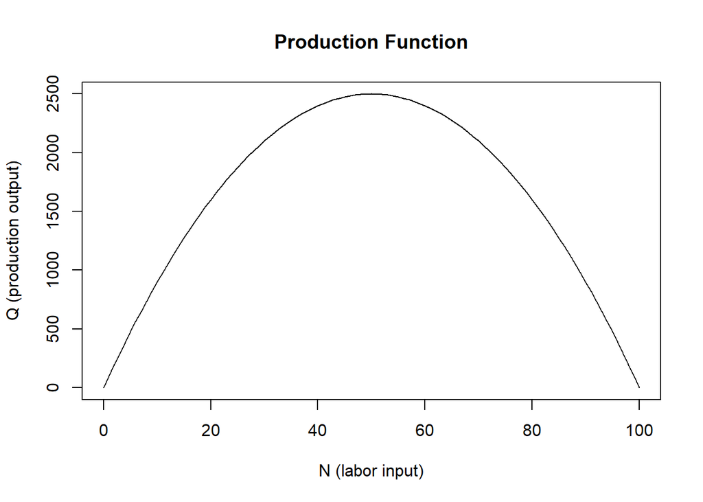

```r
curve(-x^2 + 100*x, from = 0, to = 100, xlab = 'N (labor input)', ylab = 'Q (production output)', main = 'Production Function')
```

Testing for min, max:
$$\begin{equation}
\begin{aligned}
Q'(N_0 - 1) & = Q'(49) \qquad & Q'(N_0 + 1) & = Q'(51) \\
Q'(N_0 - 1) & = -2(49) + 100 & Q'(N_0 + 1) & = -2(51) + 100 \\
Q'(N_0 - 1) & = 2 > 0 & Q'(N_0 + 1) & = -2 < 0
\end{aligned}
\end{equation}$$

Finding $Q(50)$:
$$\begin{equation}
\begin{aligned}
Q(50) & = 100(50) - (50)^2 \\
Q(50) & = 2500
\end{aligned}
\end{equation}$$

**We see that the function is increasing on $(0,50)$, and decreasing on $(50,\infty)$** **Thus, the absolute maxima of the function is at $(50,2500)$, i.e.** **This means $N = 50$ is needed to maximize output.**

# **Question 4**

## a. $q = 100 - 1.6p$, when price is p = 45.00

At $p = 45$: $q = 100 - (1.6)(45) = 28$ We know the price elasticity of demand _p is given by:

$$\begin{equation}
\begin{aligned}
\epsilon_p & = \frac{dq}{dp}.\frac{p}{q} \\
& = (-1.6).\frac{45}{28} \\
& = -\frac{18}{7} \\
& \approx -2.571429
\end{aligned}
\end{equation}$$

## b. $q = \frac{100}{p^3}$, when price is p = 20.00

At $p = 20$: $q = \frac{100}{20^3} = \frac{1}{80}$ We know the price elasticity of demand _p is given by:

$$\begin{equation}
\begin{aligned}
\epsilon_p & = \frac{dq}{dp}.\frac{p}{q} \\
& = \frac{-300}{p^4}.\frac{20}{\frac{1}{80}} \\
& = \frac{-300(20)(80)}{20^4} \\
& = -3
\end{aligned}
\end{equation}$$

## c. $q = 10p^{-1.8}.y^{.6}$, when price is p = 20.30 and income y = 5800.00

At $p = 20.30$ and $y = 5800$: $q = 10.(20.30)^{-1.8}.(5800)^{.6} \approx 8.027197$ We know the price elasticity of demand _p is given by:

$$\begin{equation}
\begin{aligned}
\epsilon_p & = \frac{\partial q}{\partial p}.\frac{p}{q} \\
& = [10.y^{.6}.(-1.8).p^{-2.8}].\frac{20.30}{8.027197} \\
& = [10.(5800)^{.6}.(-1.8).(20.30)^{-2.8}].\frac{20.30}{8.027197} \\
& = -1.8
\end{aligned}
\end{equation}$$

# **Question 5**

Total cost function $TC = 10 + 26q - 3.5q^2 + \frac{1}{3}q^3$

## a. Graph the function:

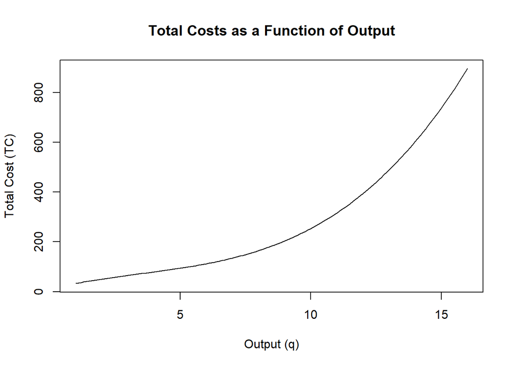

```r
# Total Cost
tc <- function(x) 10 + 26*x - 3.5*x^2 + (1/3)*x^3
x <- seq(1,16,.1)
plot(x, tc(x), type = 'l', xlab = 'Output (q)', ylab = 'Total Cost (TC)', main = 'Total Costs as a Function of Output', col = 'black')
```

## b. Average Total Cost:

The average total cost is the total cost divided by quantity of output, i.e.: $ATC = \frac{TC}{q} = \frac{10}{q} + 26 - 3.5q + \frac{1}{3}q^2$ Graph of the function:

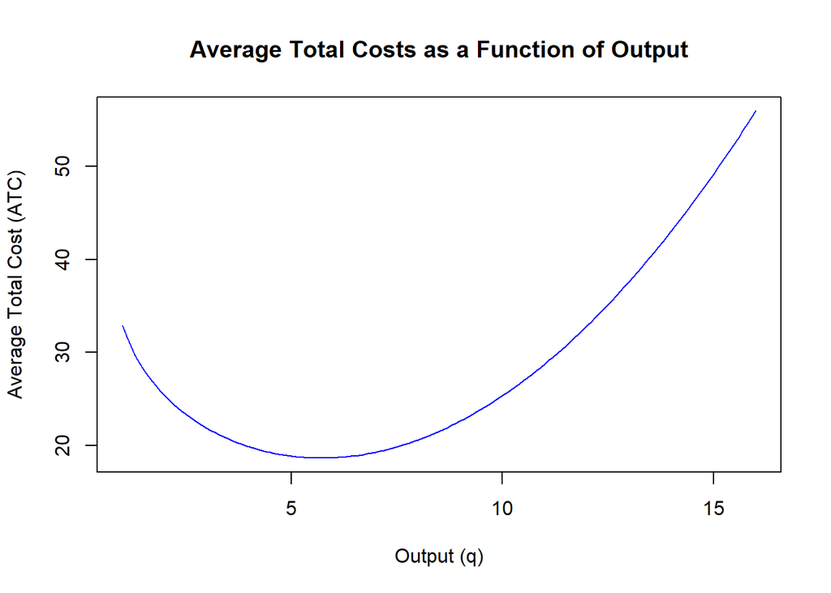

```r
atc <- function(x) (10/x) + 26 - 3.5*x + (1/3)*x^2
plot(x, atc(x), type = 'l', xlab = 'Output (q)', ylab = 'Average Total Cost (ATC)', main = 'Average Total Costs as a Function of Output', col = 'blue')
```

## c. Average Variable Cost:

[figure not shown]

```r
avc <- function(x) 26 - 3.5*x + (1/3)*x^2
plot(x, atc(x), type = 'l', xlab = 'Output (q)', ylab = 'Average Variable Cost (AVC)', main = 'Average Variable Costs as a Function of Output', col = 'red')
```

## d. Marginal Cost:

The marginal cost is the change in total cost relative to the change in quantity of output.

Thus:
$$\begin{equation}
\begin{aligned}
MC(q) & = \frac{\Delta_{TC}}{\Delta_q} \\
& = c'(q) \\
& = \frac{d_TC}{dq} \\
& = 26 - 7q + q^2
\end{aligned}
\end{equation}$$

Graph of the function:

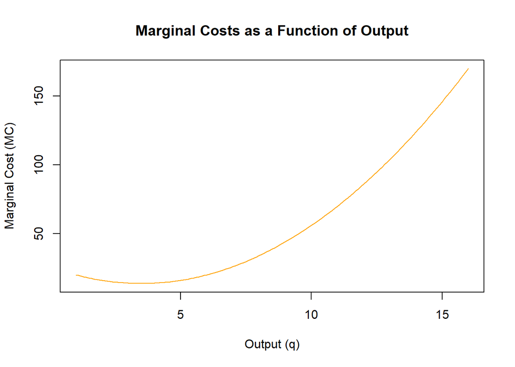

```r
mc <- function(x) 26 - 7*x + x^2
plot(x, mc(x), type = 'l', xlab = 'Output (q)', ylab = 'Marginal Cost (MC)', main = 'Marginal Costs as a Function of Output', col = 'orange')
```

## e. ATC, AVC, MC in one coordinate

Graphs:

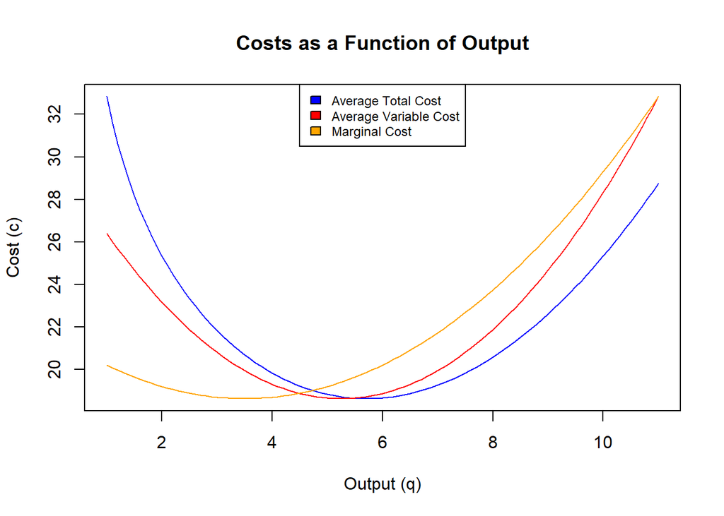

```r
x <- seq(1,11,.1)
# Average Total Cost curve
plot(x, atc(x), type = "l", xlab = "Output (q)", ylab = "Cost (c)", main = "Costs as a Function of Output", col = "blue")
par(new = TRUE)

# Average Variable Cost curve
plot(x, avc(x), type = "l", xaxt = "n", yaxt = "n", xlab = "", ylab = "", col = "red")
par(new = TRUE)

# Marginal Cost curve
plot(x, mc(x), type = "l", xaxt = "n", yaxt = "n", xlab = "", ylab = "", col = "orange")

# Add legend
legend("top", c("Average Total Cost", "Average Variable Cost", "Marginal Cost"), cex = 0.75, fill = c("blue", "red", "orange"))
```